# Disaster Tweets Analysis

Today, social media has become a very important source of information. Like other platforms, Twitter has developed into a platform to get the first hand information from the people directly involved in certain events. The informations and updates of natural disasters can be easily collected from multiple official sources; however, the tweets about such disasters provide the ground realities from the people affected by them.

So, in the analysis below we will use NLP and machine learning to generate some meaningful insights from the given tweets data. We will look at the most common disasters that were tweeted, and the popular words and hastags that are used in such tweets. We will also use ML to identify if a tweet is actually about a disater or not.

### Importing libraries for analysis

```python
import pandas as pd
import numpy as np
from matplotlib import pyplot as plt
import seaborn as sns
```

```python
#!pip install wordcloud
from wordcloud import WordCloud
```

```python
import regex as re
#!pip install emoji
import emoji
```

```python
from nltk import tokenize
from nltk.tokenize import TweetTokenizer
from nltk.corpus import stopwords
from nltk.stem import WordNetLemmatizer
```

### Importing Tweets Dataset

```python
tweets = pd.read_csv('tweets.csv')
tweets.head()
```

|  | id | keyword | location | text | target |
| --- | --- | --- | --- | --- | --- |
| 0 | 0 | ablaze | NaN | Communal violence in Bhainsa, Telangana. "Ston... | 1 |
| 1 | 1 | ablaze | NaN | Telangana: Section 144 has been imposed in Bha... | 1 |
| 2 | 2 | ablaze | New York City | Arsonist sets cars ablaze at dealership https:... | 1 |
| 3 | 3 | ablaze | Morgantown, WV | Arsonist sets cars ablaze at dealership https:... | 1 |
| 4 | 4 | ablaze | NaN | "Lord Jesus, your love brings freedom and pard... | 0 |

Id: Unique identifier for each tweet

text: Shows the text of the tweet

location: Shows the location the tweet was sent from

keyword: Keyword from the tweet to identify a disaster

target: Shows whether a tweet is about a real disaster (1) or not (0)

### Data Overview

```python
tweets['text'].values[4]
```

```
'"Lord Jesus, your love brings freedom and pardon. Fill me with your Holy Spirit and set my heart ablaze with your l… https://t.co/VlTznnPNi8'
```

```python
tweets.info()
```

```
<class 'pandas.core.frame.DataFrame'>
RangeIndex: 11370 entries, 0 to 11369
Data columns (total 5 columns):
 #   Column    Non-Null Count  Dtype
---  ------    --------------  -----
 0   id        11370 non-null  int64
 1   keyword   11370 non-null  object
 2   location  7952 non-null   object
 3   text      11370 non-null  object
 4   target    11370 non-null  int64
dtypes: int64(2), object(3)
memory usage: 444.3+ KB
```

#### Null count

```python
tweets.isna().sum()/tweets.count()
```

```
id          0.000000
keyword     0.000000
location    0.429829
text        0.000000
target      0.000000
dtype: float64
```

### Data cleaning

#### Drop unrequired columns

```python
tweets['location'].value_counts()
```

```
United States              96
Australia                  83
London, England            81
UK                         77
India                      74
                           ..
Great State of Texas        1
Karatina, Kenya             1
The internet or the gym     1
Reston, VA                  1
auroraborealis              1
Name: location, Length: 4504, dtype: int64
```

```python
tweets.drop(columns = ['location'], inplace = True)
```

```python
tweets.head(3)
```

|  | id | keyword | text | target |
| --- | --- | --- | --- | --- |
| 0 | 0 | ablaze | Communal violence in Bhainsa, Telangana. "Ston... | 1 |
| 1 | 1 | ablaze | Telangana: Section 144 has been imposed in Bha... | 1 |
| 2 | 2 | ablaze | Arsonist sets cars ablaze at dealership https:... | 1 |

### Extracting HashTags

```python
tkn = TweetTokenizer()
```

```python
tweets['tokenized'] = tweets['text'].apply(lambda words: [w for w in tkn.tokenize(words)])
```

```python
tweets['hashtags'] = tweets['tokenized'].apply(lambda words: [re.sub(r'#(.+)',r'\1',w) for w in words if re.match('#.+',w)!=None])
```

```python
tweets.drop(columns='tokenized', inplace=True)
```

```python
tweets[tweets['hashtags'].apply(lambda x: len(x)>0)].head()
```

|  | id | keyword | text | target | hashtags |
| --- | --- | --- | --- | --- | --- |
| 10 | 10 | ablaze | Images showing the havoc caused by the #Camero... | 1 | [Cameroon, Oku] |
| 11 | 11 | ablaze | Social media went bananas after Chuba Hubbard ... | 0 | [okstate] |
| 13 | 13 | ablaze | Under #MamataBanerjee political violence &amp;... | 1 | [MamataBanerjee] |
| 15 | 15 | ablaze | Images showing the havoc caused by the #Camero... | 1 | [Cameroon, Oku] |
| 16 | 16 | ablaze | No cows today but our local factory is sadly s... | 1 | [REDJanuary2020] |

#### Hashtags frequency

```python
from collections import Counter
tags_freq = Counter()

for word in tweets['hashtags']:
    tags_freq.update(word)

print(tags_freq.most_common(50))
```

```
[('Iran', 24), ('StormBrendan', 22), ('China', 14), ('earthquake', 13), ('iHeartAwards', 12), ('NeelumValley', 11), ('TaalVolcano', 11), ('PuertoRico', 9), ('Kashmir', 9), ('bushfires', 9), ('vichazmat', 9), ('Hitchin', 9), ('auspol', 8), ('NowPlaying', 8), ('Israel', 8), ('abc730', 8), ('TaalErupti…
```

The top 50 hashtags as seen above provide very limited useful information about the natural disasters. So, it is hard to rely on hashtags information to make any inference about any diaster.

### Cleaning tweets' text

```python
def data_prep(tweet):
    tweet = tweet.lower()
    tweet = re.sub("@[A-Za-z0-9]+","",tweet) #Remove @ sign
    tweet = re.sub(r'https?://\S+', '', tweet) # remove URLs
    tweet = re.sub(r'[^a-zA-Z0-9\s]', '', tweet) # remove punctuation and special characters
    tweet = re.sub(r"#", "", tweet)

    return tweet
```

```python
tweets['text1'] = tweets['text'].apply(data_prep)
```

```python
tweets.head(3)
```

|  | id | keyword | text | target | hashtags | text1 |
| --- | --- | --- | --- | --- | --- | --- |
| 0 | 0 | ablaze | Communal violence in Bhainsa, Telangana. "Ston... | 1 | [] | communal violence in bhainsa telangana stones ... |
| 1 | 1 | ablaze | Telangana: Section 144 has been imposed in Bha... | 1 | [] | telangana section 144 has been imposed in bhai... |
| 2 | 2 | ablaze | Arsonist sets cars ablaze at dealership https:... | 1 | [] | arsonist sets cars ablaze at dealership |

#### Remove duplicate tweets

```python
tweets.drop_duplicates(['text1'], keep = 'first', inplace = True)
```

```python
tweets.shape
```

```
(10965, 6)
```

### Word Tokenization

Tokenization is used in natural language processing to split paragraphs and sentences into smaller units that can be more easily assigned meaning. The first step of the NLP process is gathering the data (a sentence) and breaking it into understandable parts (words).

```python
tnk = TweetTokenizer()
```

```python
tweets['t_words'] = tweets['text1'].apply(tnk.tokenize)
```

```python
tweets.head()
```

|  | id | keyword | text | target | hashtags | text1 | t_words |
| --- | --- | --- | --- | --- | --- | --- | --- |
| 0 | 0 | ablaze | Communal violence in Bhainsa, Telangana. "Ston... | 1 | [] | communal violence in bhainsa telangana stones ... | [communal, violence, in, bhainsa, telangana, s... |
| 1 | 1 | ablaze | Telangana: Section 144 has been imposed in Bha... | 1 | [] | telangana section 144 has been imposed in bhai... | [telangana, section, 144, has, been, imposed, ... |
| 2 | 2 | ablaze | Arsonist sets cars ablaze at dealership https:... | 1 | [] | arsonist sets cars ablaze at dealership | [arsonist, sets, cars, ablaze, at, dealership] |
| 3 | 3 | ablaze | Arsonist sets cars ablaze at dealership https:... | 1 | [] | arsonist sets cars ablaze at dealership | [arsonist, sets, cars, ablaze, at, dealership] |
| 4 | 4 | ablaze | "Lord Jesus, your love brings freedom and pard... | 0 | [] | lord jesus your love brings freedom and pardon... | [lord, jesus, your, love, brings, freedom, and... |

### Stopwords

In NLP and text mining applications, stop words are used to eliminate unimportant words, allowing applications to focus on the important words instead.

```python
stpwrd = stopwords.words('english')
```

```python
len(stpwrd)
```

```
179
```

```python
tweets['filtered'] = tweets['t_words'].apply(lambda words: [word for word in words if word not in stpwrd])
```

```python
tweets.head(3)
```

|  | id | keyword | text | target | hashtags | text1 | t_words | filtered |
| --- | --- | --- | --- | --- | --- | --- | --- | --- |
| 0 | 0 | ablaze | Communal violence in Bhainsa, Telangana. "Ston... | 1 | [] | communal violence in bhainsa telangana stones ... | [communal, violence, in, bhainsa, telangana, s... | [communal, violence, bhainsa, telangana, stone... |
| 1 | 1 | ablaze | Telangana: Section 144 has been imposed in Bha... | 1 | [] | telangana section 144 has been imposed in bhai... | [telangana, section, 144, has, been, imposed, ... | [telangana, section, 144, imposed, bhainsa, ja... |
| 2 | 2 | ablaze | Arsonist sets cars ablaze at dealership https:... | 1 | [] | arsonist sets cars ablaze at dealership | [arsonist, sets, cars, ablaze, at, dealership] | [arsonist, sets, cars, ablaze, dealership] |

### Lemmatization

Lemmatization is a text pre-processing technique used in natural language processing (NLP) models to break a word down to its root meaning to identify similarities. For example, a lemmatization algorithm would reduce the word better to its root word, or lemme, good.

```python
lem = WordNetLemmatizer()

tweets['words'] = tweets['filtered'].apply(lambda words: [lem.lemmatize(w) for w in words])

tweets.head()
```

|  | id | keyword | text | target | hashtags | text1 | t_words | filtered | words |
| --- | --- | --- | --- | --- | --- | --- | --- | --- | --- |
| 0 | 0 | ablaze | Communal violence in Bhainsa, Telangana. "Ston... | 1 | [] | communal violence in bhainsa telangana stones ... | [communal, violence, in, bhainsa, telangana, s... | [communal, violence, bhainsa, telangana, stone... | [communal, violence, bhainsa, telangana, stone... |
| 1 | 1 | ablaze | Telangana: Section 144 has been imposed in Bha... | 1 | [] | telangana section 144 has been imposed in bhai... | [telangana, section, 144, has, been, imposed, ... | [telangana, section, 144, imposed, bhainsa, ja... | [telangana, section, 144, imposed, bhainsa, ja... |
| 2 | 2 | ablaze | Arsonist sets cars ablaze at dealership https:... | 1 | [] | arsonist sets cars ablaze at dealership | [arsonist, sets, cars, ablaze, at, dealership] | [arsonist, sets, cars, ablaze, dealership] | [arsonist, set, car, ablaze, dealership] |
| 3 | 3 | ablaze | Arsonist sets cars ablaze at dealership https:... | 1 | [] | arsonist sets cars ablaze at dealership | [arsonist, sets, cars, ablaze, at, dealership] | [arsonist, sets, cars, ablaze, dealership] | [arsonist, set, car, ablaze, dealership] |
| 4 | 4 | ablaze | "Lord Jesus, your love brings freedom and pard... | 0 | [] | lord jesus your love brings freedom and pardon... | [lord, jesus, your, love, brings, freedom, and... | [lord, jesus, love, brings, freedom, pardon, f... | [lord, jesus, love, brings, freedom, pardon, f... |

### Cleaning Keywords

Keywords shows the word related to disasters. However, in case of some tweets which are not related to disaster, the keyword can be misleading. So below analysis will show top keywords.

```python
tweets['keyword'] = tweets['keyword'].apply(lambda x : x.replace("%20"," "))
tweets['root_keyword'] = tweets['keyword'].apply(lambda words: " ".join([lem.lemmatize(w) for w in words.split(" ")]))
```

```python
tweets[tweets['keyword'] != tweets['root_keyword']][['keyword','root_keyword']].drop_duplicates()
```

|  | keyword | root_keyword |
| --- | --- | --- |
| 1404 | body bags | body bag |
| 1682 | buildings burning | building burning |
| 1750 | buildings on fire | building on fire |
| 1924 | bush fires | bush fire |
| 1994 | casualties | casualty |
| 3178 | deaths | death |
| 4830 | emergency services | emergency service |
| 5351 | fatalities | fatality |
| 5645 | first responders | first responder |
| 5693 | flames | flame |
| 5913 | floods | flood |
| 5989 | forest fires | forest fire |
| 6634 | hostages | hostage |
| 6796 | injuries | injury |
| 8451 | refugees | refugee |
| 8592 | rescuers | rescuer |
| 9024 | screams | scream |
| 9243 | sirens | siren |
| 9921 | survivors | survivor |
| 10921 | weapons | weapon |
| 11012 | wild fires | wild fire |
| 11185 | wounds | wound |

```python
tweets['root_keyword'].replace('building burning','building on fire', inplace=True)
```

```python
tweets[tweets['root_keyword']=='building burning']
```

|  | id | keyword | text | target | hashtags | text1 | t_words | filtered | words | root_keyword |
| --- | --- | --- | --- | --- | --- | --- | --- | --- | --- | --- |

### Keywords analysis

```python
disasters = tweets[tweets['target']==1][['root_keyword','words']]
disasters.head()
```

|  | root_keyword | words |
| --- | --- | --- |
| 0 | ablaze | [communal, violence, bhainsa, telangana, stone... |
| 1 | ablaze | [telangana, section, 144, imposed, bhainsa, ja... |
| 2 | ablaze | [arsonist, set, car, ablaze, dealership] |
| 3 | ablaze | [arsonist, set, car, ablaze, dealership] |
| 6 | ablaze | [several, house, set, ablaze, ngemsibaa, villa... |

```python
top_10_disaster = disasters['root_keyword'].value_counts().to_frame().reset_index()[:10]
top_10_disaster.columns =  ['root_keyword','count']
top_10_disaster
```

|  | root_keyword | count |
| --- | --- | --- |
| 0 | thunderstorm | 69 |
| 1 | collision | 53 |
| 2 | derailment | 53 |
| 3 | sinkhole | 38 |
| 4 | building on fire | 38 |
| 5 | body bag | 34 |
| 6 | hazardous | 31 |
| 7 | injury | 31 |
| 8 | casualty | 31 |
| 9 | derailed | 27 |

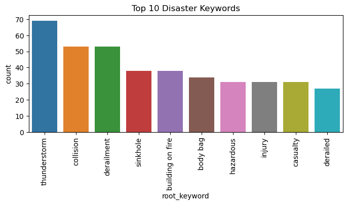

```python
plt.figure(figsize=(8,3))
sns.barplot(data = top_10_disaster, x= 'root_keyword', y='count')
plt.xticks(rotation = 90)
plt.title("Top 10 Disaster Keywords")
plt.show()
```

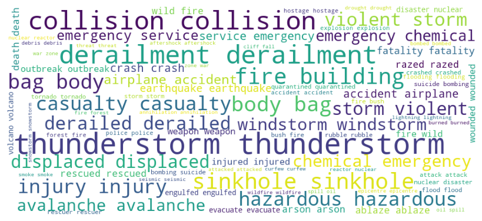

```python
disaster_words = ''
disaster_words += " ".join(disasters['root_keyword'])+" "

wordcloud = WordCloud(width = 900, height = 400,
                background_color ='white',
                stopwords = stpwrd,
                min_font_size = 10).generate(disaster_words)

# plot the WordCloud image
plt.figure(figsize = (8, 8), facecolor = None)
plt.imshow(wordcloud)
plt.axis("off")
plt.tight_layout(pad = 0)

plt.show()
```

```python
others = tweets[tweets['target']==0][['text1','root_keyword','words']]

top_10_other = others['root_keyword'].value_counts().to_frame().reset_index()[:10]
top_10_other.columns =  ['root_keyword','count']
top_10_other
```

|  | root_keyword | count |
| --- | --- | --- |
| 0 | death | 125 |
| 1 | hostage | 121 |
| 2 | weapon | 108 |
| 3 | body bag | 98 |
| 4 | fatality | 98 |
| 5 | building on fire | 93 |
| 6 | siren | 84 |
| 7 | injury | 79 |
| 8 | fear | 76 |
| 9 | mass murder | 76 |

Keywords like 'Mass Murder' do sound like disaster. However, if you look at the original tweets, those terms are not real disasters, they are just used as expressions, hypothetical situtations or exaggerations!

```python
others[others['root_keyword']=='mass murder']['text1'][7316]
```

```
'trumps actually a genius he takes out the mass murder while obama funded him '
```

```python
others[others['root_keyword']=='building on fire']['text1'][1683]
```

```
'how many burning buildings have you run into to save someone'
```

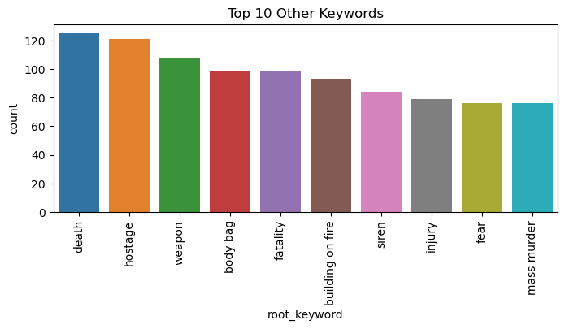

```python
plt.figure(figsize=(8,3))
sns.barplot(data = top_10_other, x= 'root_keyword', y='count')
plt.xticks(rotation = 90)
plt.title("Top 10 Other Keywords")
plt.show()
```

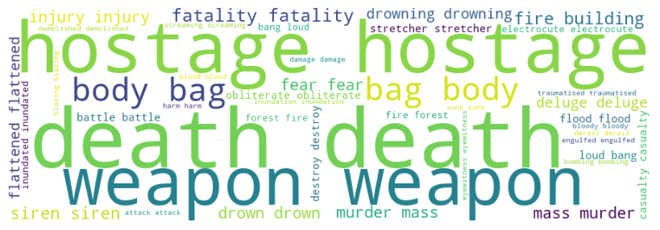

```python
disaster_words = ''
disaster_words += " ".join(others['root_keyword'])+" "

wordcloud = WordCloud(width = 900, height = 300,
                background_color ='white',
                stopwords = stpwrd,
                min_font_size = 10).generate(disaster_words)

# plot the WordCloud image
plt.figure(figsize = (8, 8), facecolor = None)
plt.imshow(wordcloud)
plt.axis("off")
plt.tight_layout(pad = 0)

plt.show()
```

### TF-IDF vectorizer

TF-IDF (Term Frequency - Inverse Document Frequency) is a handy algorithm that uses the frequency of words to determine how relevant those words are to a given document. It's a relatively simple but intuitive approach to weighting words, allowing it to act as a great jumping off point for a variety of tasks.

```python
from sklearn.feature_extraction.text import TfidfVectorizer
```

```python
vectorizer = TfidfVectorizer()
X = vectorizer.fit_transform(tweets['text1'])
vectorizer.get_feature_names_out()
```

```
array(['000009', '0019', '007', ..., 'zuma', 'zurich', 'zw'], dtype=object)
```

### Train Test Split

```python
X = X.toarray()
y = tweets['target']
```

```python
from sklearn.model_selection import train_test_split
```

```python
X_train, X_test, y_train, y_test=train_test_split(X, y, train_size=0.8)
```

### Modelling

#### Logistic Regression

Logistic regression is a supervised machine learning algorithm mainly used for classification tasks where the goal is to predict the probability that an instance of belonging to a given class or not. It is a kind of statistical algorithm, which analyze the relationship between a set of independent variables and the dependent binary variables. It is a powerful tool for decision-making.

```python
from sklearn.linear_model import LogisticRegression
lr = LogisticRegression(penalty='l2',class_weight='balanced', verbose=1)
```

```python
lr.fit(X_train,y_train)
y_hat_lr = lr.predict(X_test)
```

```
[Parallel(n_jobs=1)]: Using backend SequentialBackend with 1 concurrent workers.
[Parallel(n_jobs=1)]: Done   1 out of   1 | elapsed:    6.5s finished
```

```python
print(y_hat_lr.shape, y_test.shape)
```

```
(2193,) (2193,)
```

```python
from sklearn import metrics

metrics.accuracy_score(y_test, y_hat_lr)
```

```
0.8873689010487916
```

```python
metrics.confusion_matrix(y_test, y_hat_lr)
```

```
array([[1641,  145],
       [ 102,  305]], dtype=int64)
```

#### Naive Bayes

The Naive Bayes family of statistical algorithms are some of the most used algorithms in text classification and text analysis , and one of the members of that family is Multinational Naive Bayes (MNB) with a huge advantage, that you can get really good results even when your data set isn’t very large (a couple of thousand tagged samples) and computational resources are scarce.

```python
from sklearn.naive_bayes import MultinomialNB
nb = MultinomialNB()         #create instance
```

```python
nb.fit(X_train, y_train)  #fit model
y_hat_nb = nb.predict(X_test)     #make prediction for entire testing set

y_hat_nb[0:10]
```

```
array([0, 0, 0, 0, 0, 0, 0, 0, 0, 0], dtype=int64)
```

```python
metrics.accuracy_score(y_test, y_hat_nb)
```

```
0.8331053351573188
```

```python
metrics.confusion_matrix(y_test, y_hat_nb)
```

```
array([[1782,    4],
       [ 362,   45]], dtype=int64)
```

Logistic Regression Model performed slightly better than Naive Bayes Model.